# Animal Sensory Mechanisms

## The fastest predator on Earth?: star-nosed mole

**Eimer’s organ: touch receptors - 120 milliseconds to identify and consume prey**

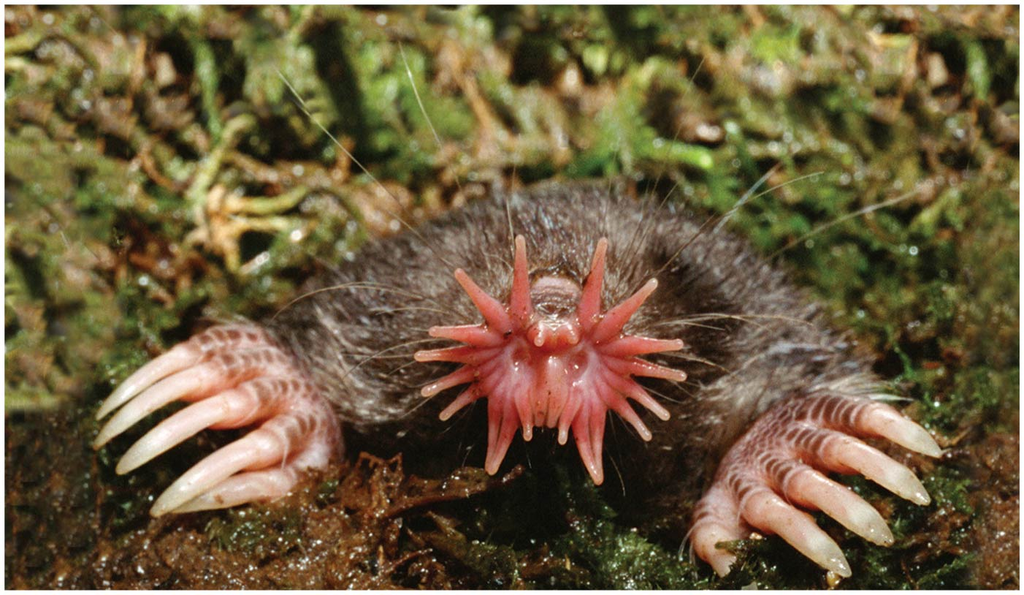

## Things to Know (#s)

- **#Neuron Structure**
- **#Sensory Pathway**
- **#Receptor Types**

## The Big Picture: Perception to Behavior

- **Sensory processes begin with stimuli**
  - stimuli are forms of energy
  - physical or chemical (energy)
  - represent internal or external signals
- **Receptors alert nervous systems (most animals)**
  - receptor = specialized protein on/in a cell
  - use *action potentials* (membrane voltage)
  - results in a ‘sensation’
- **After a stimulus is processed, a response may be generated**

[figure not shown]

## Sensory systems work through neural pathways

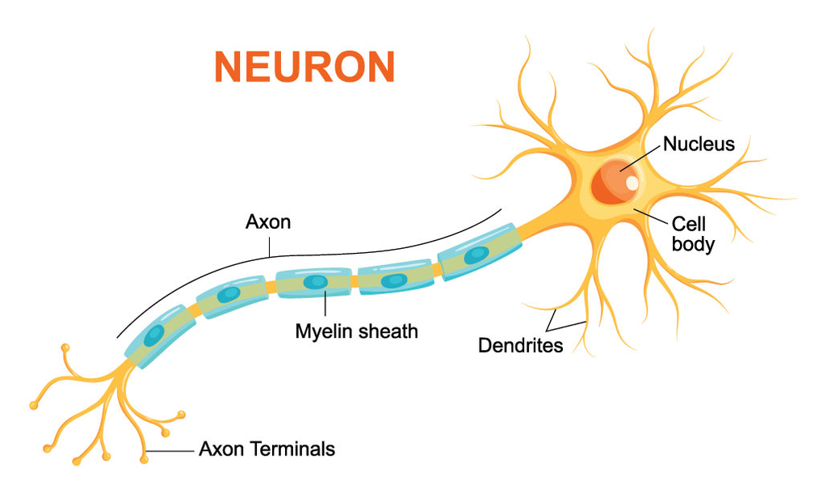

- **Neurons =**
  - sensory, interneurons, and motor neurons
  - Fundamental unit of the brain and nervous system
- **Neuron structure is all about form and function**
  - Most organelles located in the cell body
  - Highly branched extensions, called *dendrites*, receive signals from other neurons or receptors
- **Neurons have a single *axon* to transmit signals**
  - transmit pulses of electrical current
  - *terminals* connect nerve cells

## (1) Sensory Reception

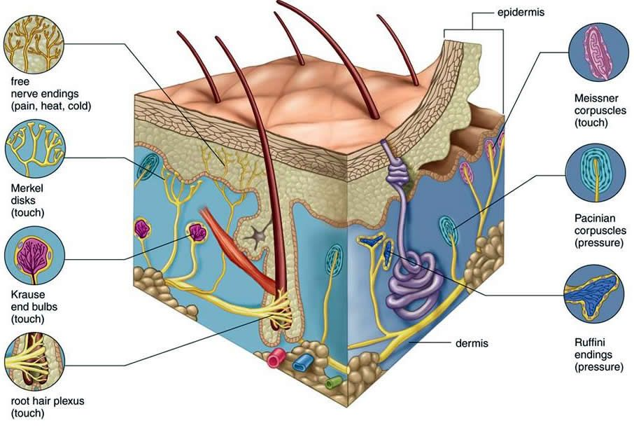

- **Sensory pathways have four basic functions:**
  - *reception, transduction, transmission, perception*
- **Sensory pathway starts with stimuli**
- **(1) Sensory reception:**
  - sensory cells are specialized neurons
  - located inside or on outside of body
  - detect specific types of stimuli

## (2) Sensory Transduction: Signal conversion

- **Transduction:**
- **Stimulus receptors change flow of ions across nerve cell membranes**
  - opens/closes ion membrane channels along axon
  - Cl<sup>-</sup>, Na<sup>+</sup>, K<sup>+</sup>, Ca<sup>+</sup>
- **Membrane potential: gradient that forces ions to passively move in one direction**
  - can be processed by central nervous system
  - at rest, inside of cell is more negative than outside
  - magnitude of change in ion flow = strength of stimulus

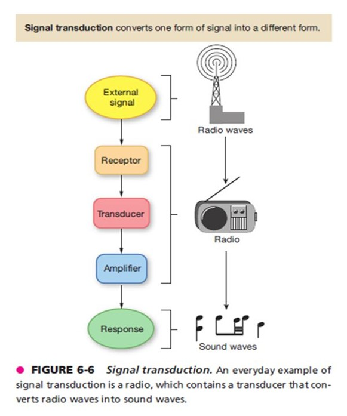

## (3) Sensory Transmission: action potentials (nerve impulse)

[figure not shown]

- **Transmission:**
- **Action potential:**
  - caused by change in membrane potential
  - travels along *axon* and flows to other cells
- **Receptor generates action potentials that travel through the nervous system**
  - large stimulus = more action potentials
- **Speed of action potential depends on species**
  - length of axons varies
  - vertebrate axons are insulated

## Action Potential further explained…

https://www.youtube.com/watch?v=XnksofQN8_s

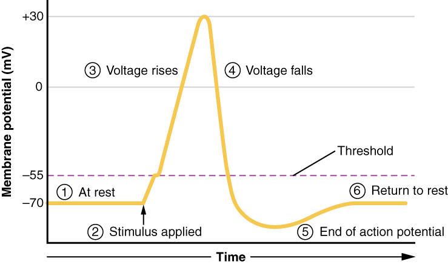

## (4) Sensory Perception: Processing the stimulus

- **Perception:**
- **How does the brain know the difference in stimuli?**
  - action potentials are not different from each other
- **Action potentials reach brain/spinal cord via dedicated neural pathways**
  - brain distinguishes stimuli on the path they arrive
  - actions potentials sent back to target receptors via neurons
  - 100 million neurons with 100 trillion connections = human brain

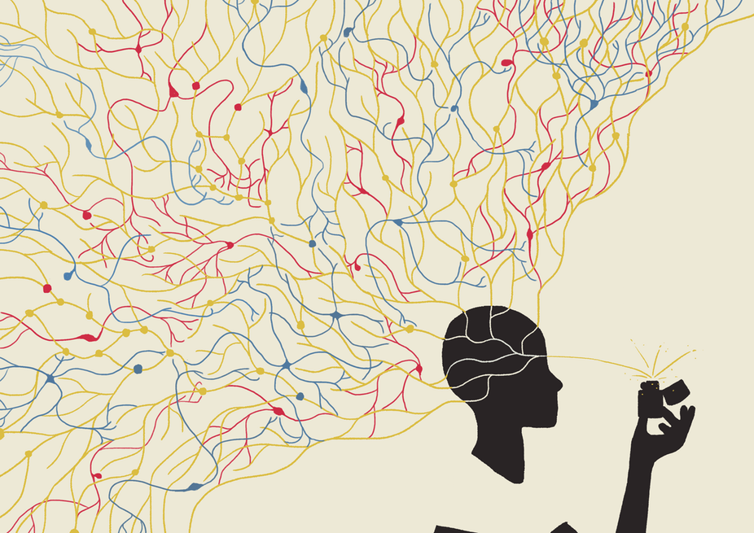

## If a tree falls in the woods……physics vs biology

[figure not shown]

[figure not shown]

## Animal sensory receptors: Mechanoreceptors

- **Response to touch, stretch, motion and sound**
  - Receptors sense physical deformation
- **Ion channels linked to structures that end outside cell**
  - hair or cilia
  - bending/stretching structure generates response
- **Touch receptors often embedded in tissues**

[figure not shown]

## Diversity of mechanoreceptors on mouse face

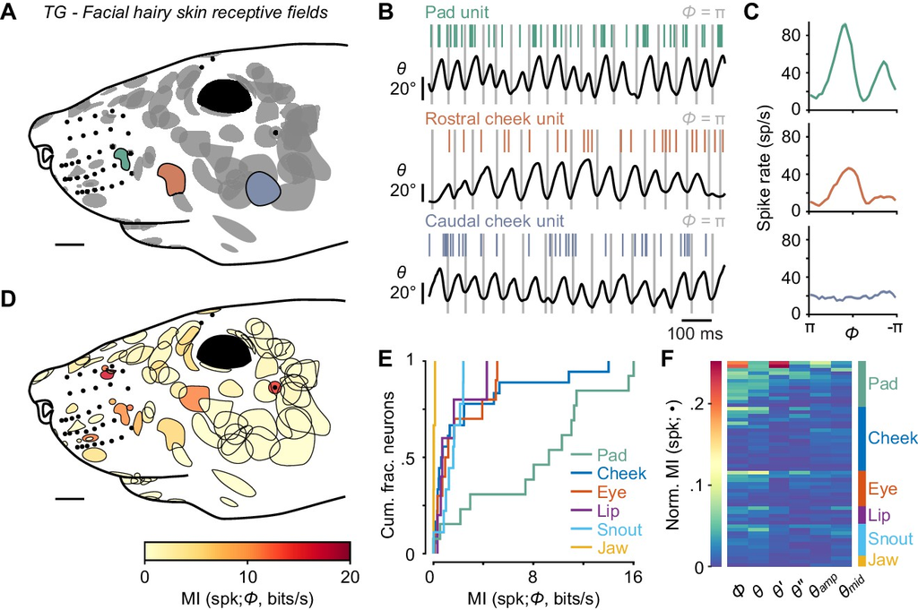

## Animal sensory receptors: Chemoreceptors

- **(1) Transmit information about solute concentrations**
  - detect change in blood solutes → stimulate thirst
- **(2) Respond to individual kinds of molecules**
  - glucose, O<sub>2</sub>, CO<sub>2</sub>, amino acids, pheromones
- **Stimulus molecule binds to a chemoreceptor**
  - silk worms detect pheromones from females several kilometers away
- **Chemoreceptor becomes more or less permeable to ions**

[figure not shown]

## Taste and smell rely on chemoreceptors

[figure not shown]

## Taste and smell rely on chemoreceptors

[figure not shown]

[figure not shown]

## Animal sensory receptors: Electromagnetic

- **Receptors that detect light, electricity and magnetism**
- **Animals create & detect electromagnetic energy to hunt, migrate, and communicate**
- **Used by animal kingdom to migrate**
  - receptors can sense Earth’s magnetic fields
  - insects, birds & mammals

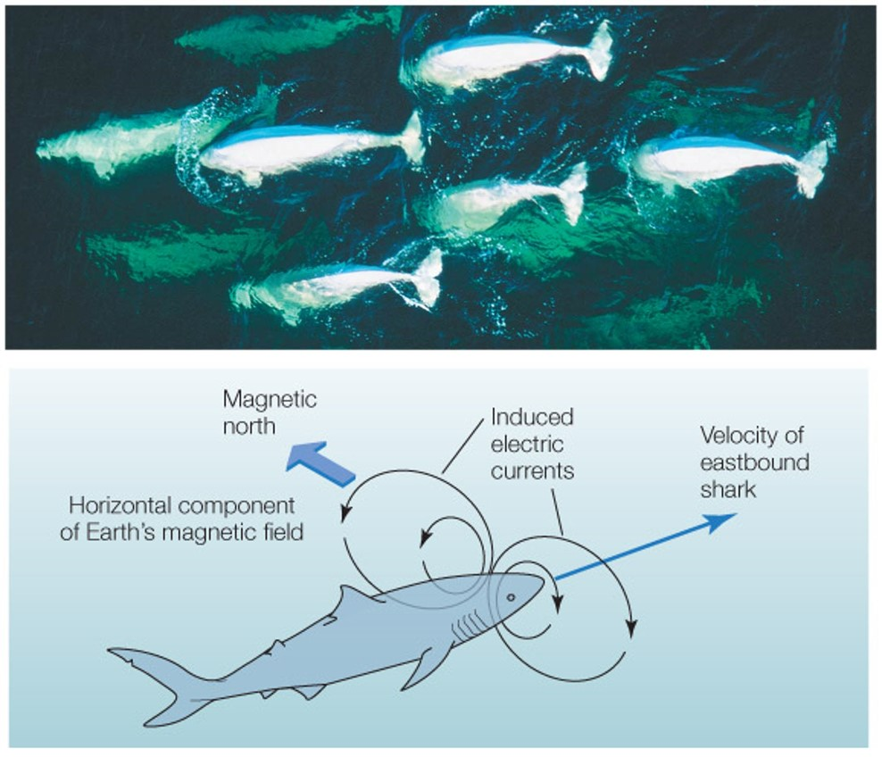

## Animal sensory receptors: Electromagnetic

- **Receptors that detect light, energy and magnetism**
- **Used widely by animals to sense prey**
  - 16% of fish species use electroreceptors to detect bioelectric fields from prey

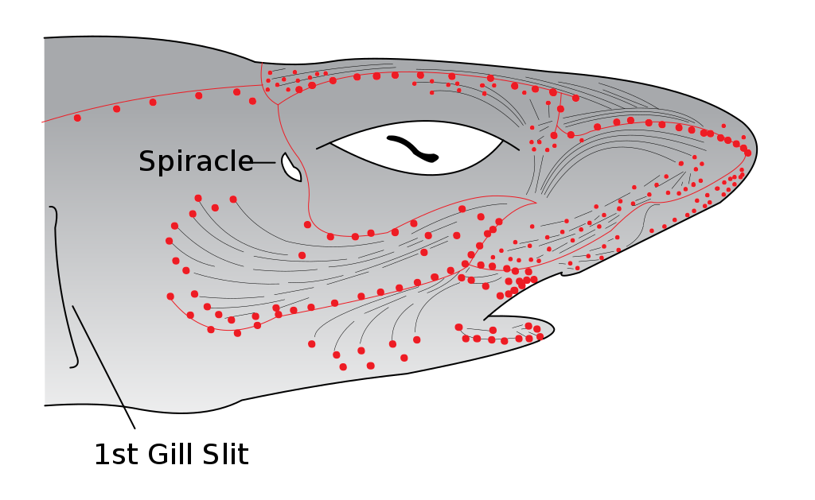

## Animal sensory receptors: Thermoreceptors

- **Receptors detect heat and cold**
- **Hot pepper science has really helped!!!**
  - Receptors that respond to capsaicin also respond to high temperatures
  - ‘spicy’ taste activates same receptors as hot soup
  - opposite for ‘cold’ flavor
- **Mammals: thermoreceptors for specific temperatures**
- **Venomous snakes: infrared receptors to detect ‘warm’ prey**

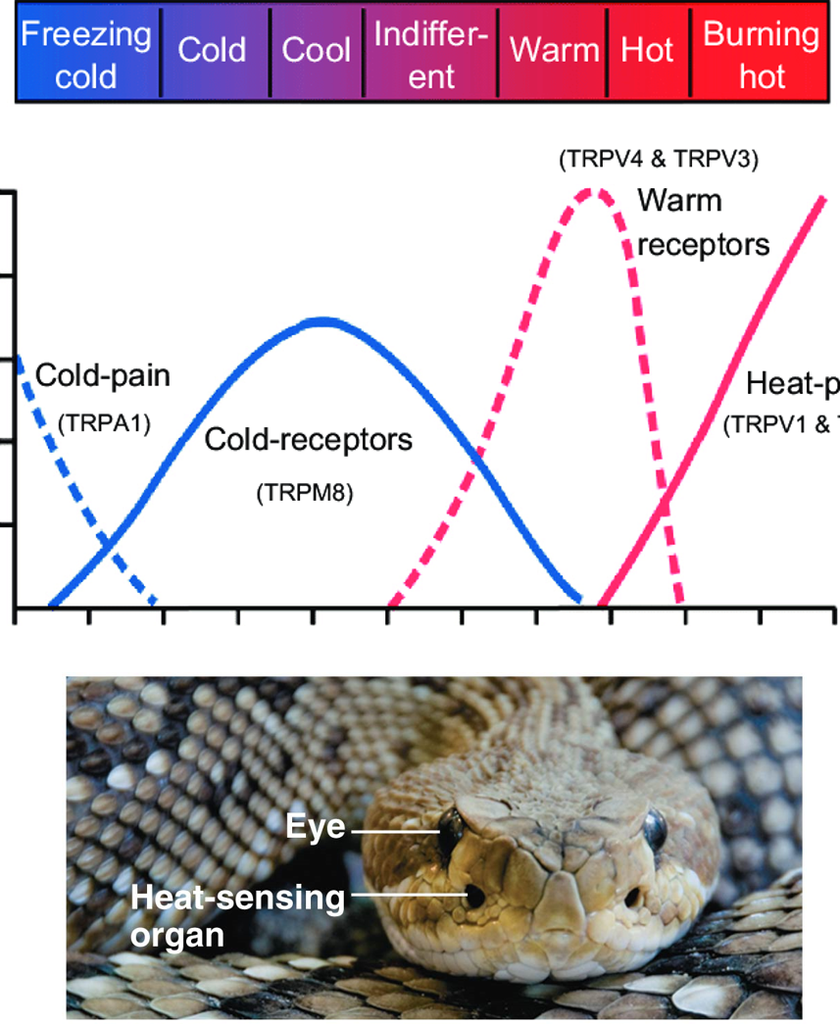

## Animal sensory receptors: Pain

- **Pain receptors (nocioreceptors) detect stimuli that reflect harmful conditions**
  - damaged or inflamed tissues
  - gene mutations can cause chronic insensitivity to pain (C.I.P.) by making nocioreceptos non-functional
- **Respond to damaged/inflamed tissues**
  - perceived as pain
  - trigger defenses (withdraw)

[figure not shown]

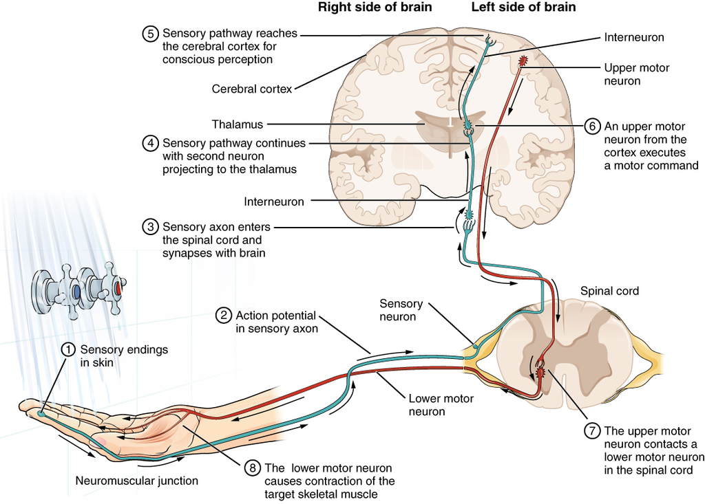